# Introduction

```python
import pandas as pd
import numpy as np
import tensorflow as tf
from tensorflow import keras
import matplotlib.pyplot as plt
import math

# df = pd.read_csv('vehicles.csv', nrows=10000)
df = pd.read_csv('vehicles.csv')
df.columns
```

```
Index(['id', 'url', 'region', 'region_url', 'price', 'year', 'manufacturer',
       'model', 'condition', 'cylinders', 'fuel', 'odometer', 'title_status',
       'transmission', 'VIN', 'drive', 'size', 'type', 'paint_color',
       'image_url', 'description', 'county', 'state', 'lat', 'long',
       'posting_date'],
      dtype='object')
```

# Data Cleaning & Preprocessing

```python
# Step 1: Perform log transform on 'price' to stabilize training
df['price_backup'] = df['price']
df['price'] = np.log(df['price'] + 1)  # avoid log(0) issue

# Step 2: Drop rows with missing critical fields
df = df.dropna(subset=['VIN', 'price', 'posting_date'])
df = df[df['price'] > 0]
df = df[df['VIN'] != '']

# Step 3: Forward-fill other missing values (if any)
df.fillna(method="ffill", inplace=True)

# Step 4: Convert 'posting_date' to datetime and sort by VIN & date
df['posting_date'] = pd.to_datetime(df['posting_date'])
df = df.sort_values(by=['VIN', 'posting_date'])

# Step 5: Create "brand_model" for embedding usage
df['brand_model'] = df['manufacturer'].astype(str) + '_' + df['model'].astype(str)

# Step 6: Encode VIN and brand_model as integer IDs
vin_list = df['VIN'].unique().tolist()
vin_to_id = {v: i for i, v in enumerate(vin_list)}
df['vin_id'] = df['VIN'].map(vin_to_id)

bm_list = df['brand_model'].unique().tolist()
bm_to_id = {bm: i for i, bm in enumerate(bm_list)}
df['bm_id'] = df['brand_model'].map(bm_to_id)

# Step 7: Decide numeric columns to feed into the model
numeric_cols = ['price', 'odometer', 'year']
```

```python
# =============================================================================
# 2. BUILD SEQUENCES WITH SLIDING WINDOW
# =============================================================================

seq_len = 3  # we use the previous 3 records to predict the next one

data_sequences = []
grouped = df.groupby('VIN', sort=False)

for vin, group in grouped:
    # Sort each VIN group by date
    group = group.sort_values('posting_date').reset_index(drop=True)

    # numeric_data: shape [T, len(numeric_cols)] => [price, odometer, year]
    numeric_data = group[numeric_cols].values
    # vin_ids, bm_ids => to track VIN embeddings
    vin_ids = group['vin_id'].values
    bm_ids  = group['bm_id'].values
    # date_arr => posting_date for later reference
    date_arr = group['posting_date'].values

    # If the group length is smaller than seq_len, we skip
    if len(group) <= seq_len:
        continue

    # Create sliding windows
    for start_idx in range(len(group) - seq_len):
        end_idx = start_idx + seq_len

        # X_seq_* = the previous 'seq_len' records
        X_seq_numeric = numeric_data[start_idx:end_idx]  # shape [seq_len, 3]
        X_seq_vin     = vin_ids[start_idx:end_idx]       # shape [seq_len]
        X_seq_bm      = bm_ids[start_idx:end_idx]        # shape [seq_len]

        # y_price = the log(price) at the next time step (end_idx)
        y_price = numeric_data[end_idx, 0]  # numeric_data[...,0] => price
        # y_date = posting_date at that next time step
        y_date  = date_arr[end_idx]

        # Append a tuple of 6 items:
        # (X_seq_numeric, X_seq_vin, X_seq_bm, y_price, y_date, vin_string)
        data_sequences.append((
            X_seq_numeric,
            X_seq_vin,
            X_seq_bm,
            y_price,
            y_date,
            vin  # we can keep original vin (string) for reference
        ))

print("Number of sequence samples:", len(data_sequences))
```

```
Number of sequence samples: 79870
```

```python
# =============================================================================
# 3. SPLIT DATA: 20% HOLD-OUT TEST, 80% FOR CROSS VALIDATION
# =============================================================================

# np.random.shuffle(data_sequences)
holdout_ratio = 0.2
holdout_size = int(len(data_sequences) * holdout_ratio)
test_holdout_data = data_sequences[:holdout_size]  # 20% => final test
cv_data = data_sequences[holdout_size:]            # 80% => cross validation

print("Holdout size:", holdout_size, " CV size:", len(cv_data))
```

```
Holdout size: 15974  CV size: 63896
```

===

```python
import numpy as np

def build_Xy_for_linear(data_list, seq_len=3):
    """
    data_list 每个元素: (X_seq_numeric, X_seq_vin, X_seq_bm, y_price, y_date, vin_str)
    X_seq_numeric shape = [seq_len, num_numeric_features]
    扁平化 X_seq_numeric => [seq_len * num_numeric_features]
    返回: X, y
    """
    X_list = []
    y_list = []
    for (num_seq, vin_seq, bm_seq, y, y_date, vin_str) in data_list:
        # num_seq shape => (seq_len, num_numeric_features)
        # flatten:
        x_flat = num_seq.flatten()  # shape (seq_len * num_numeric_features,)

        X_list.append(x_flat)
        y_list.append(y)

    X = np.array(X_list, dtype=np.float32)
    y = np.array(y_list, dtype=np.float32)
    return X, y
```

```python
import pandas as pd
import numpy as np
import matplotlib.pyplot as plt
from sklearn.linear_model import Ridge
from sklearn.model_selection import KFold, GridSearchCV
import math

# -- 假设 data_sequences 已准备好
# Shuffle + 拆分 holdout
# np.random.shuffle(data_sequences)
holdout_ratio = 0.2
holdout_size = int(len(data_sequences) * holdout_ratio)
test_holdout_data = data_sequences[:holdout_size]
cv_data = data_sequences[holdout_size:]

# 先把 holdout 转成 X_test, y_test
X_test, y_test = build_Xy_for_linear(test_holdout_data, seq_len=3)
```

```python
# 先把 cv_data 转成 X_cv, y_cv
X_cv, y_cv = build_Xy_for_linear(cv_data, seq_len=3)

# 构造 param_grid
param_grid = {
    'alpha': [0.01, 0.1, 1.0, 10.0, 100.0]  # 只演示一下
}

# 建立模型: Ridge
ridge_model = Ridge()

# 用 scikit-learn 的 GridSearchCV
kfold = KFold(n_splits=3, shuffle=True, random_state=42)
grid_search = GridSearchCV(ridge_model, param_grid, cv=kfold, scoring='neg_mean_squared_error', n_jobs=-1)
grid_search.fit(X_cv, y_cv)

# 输出最优结果
best_alpha = grid_search.best_params_['alpha']
best_score = grid_search.best_score_  # 注意这是 -MSE
print("Best alpha:", best_alpha)
print("Best CV MSE:", -best_score)
```

```
Best alpha: 10.0
Best CV MSE: 0.07300909484426181
```

```python
from sklearn.linear_model import Ridge
import numpy as np
import math
import statsmodels.api as sm

# Train final model with best_alpha
final_model = Ridge(alpha=best_alpha)
final_model.fit(X_cv, y_cv)

# Predict on test set
y_pred_test = final_model.predict(X_test)

# Calculate MSE and RMSE
mse_test = np.mean((y_pred_test - y_test)**2)
rmse_test = math.sqrt(mse_test)
print(f"Final Test MSE={mse_test:.4f}, RMSE={rmse_test:.4f}")

# Print model coefficients and intercept
print("\n--- Ridge Regression Model Summary ---")
print("Intercept:", final_model.intercept_)
print("Coefficients:")
for idx, coef in enumerate(final_model.coef_):
    print(f"  Feature {idx+1}: {coef:.4f}")

# Optionally, if you want a full statistical summary, you can use statsmodels:
# Note: For Ridge, this is a rough approximation (ignoring the regularization)
X_test_sm = sm.add_constant(X_test)
ols_model = sm.OLS(y_test, X_test_sm).fit()
print("\n--- OLS Summary (as an approximation) ---")
print(ols_model.summary())
```

```
Final Test MSE=0.0774, RMSE=0.2782

--- Ridge Regression Model Summary ---
Intercept: 0.43671417
Coefficients:
  Feature 1: 0.0649
  Feature 2: -0.0000
  Feature 3: -0.0015
  Feature 4: 0.0239
  Feature 5: -0.0000
  Feature 6: 0.0005
  Feature 7: 0.9075
  Feature 8: 0.0000
  Feature 9: 0.0008

--- OLS Summary (as an approximation) ---
                            OLS Regression Results
==============================================================================
Dep. Variable:                      y   R-squared:                       0.937
Model:                            OLS   Adj. R-squared:                  0.937
Method:                 Least Squares   F-statistic:                 2.655e+04
Date:                Mon, 10 Mar 2025   Prob (F-statistic):               0.00
Time:                        01:36:07   Log-Likelihood:                -1911.2
No. Observations:               15974   AIC:                             3842.
Df Residuals:                   15964   BIC:                             3919.
Df Model:                           9
Covariance Type:            nonrobust
==============================================================================
                 coef    std err          t      P>|t|      [0.025      0.975]
------------------------------------------------------------------------------
const          1.1990      1.126      1.065      0.287      -1.008       3.406
x1             0.0884      0.008     10.651      0.000       0.072       0.105
x2          3.783e-06   1.18e-06      3.201      0.001    1.47e-06     6.1e-06
x3             0.0043      0.002      1.789      0.074      -0.000       0.009
x4             0.1869      0.010     18.975      0.000       0.168       0.206
x5         -3.903e-06   1.13e-06     -3.455      0.001   -6.12e-06   -1.69e-06
x6            -0.0216      0.003     -6.417      0.000      -0.028      -0.015
x7             0.7202      0.008     93.962      0.000       0.705       0.735
x8          1.207e-07   7.71e-07      0.157      0.876   -1.39e-06    1.63e-06
x9             0.0167      0.003      5.831      0.000       0.011       0.022
==============================================================================
Omnibus:                    35387.305   Durbin-Watson:                   2.003
Prob(Omnibus):                  0.000   Jarque-Bera (JB):        424895763.566
Skew:                         -20.194   Prob(JB):                         0.00
Kurtosis:                     800.966   Cond. No.                     7.26e+07
==============================================================================

Notes:
[1] Standard Errors assume that the covariance matrix of the errors is correctly specified.
[2] The condition number is large, 7.26e+07. This might indicate that there are
strong multicollinearity or other numerical problems.
```

```python
def build_infer_data(data_list, seq_len=3):
    """
    返回: X_array, y_array, date_list, vin_list
    其中 X_array 是 flattened
    """
    X_list, y_list, date_list, vin_list = [], [], [], []
    for (num_seq, vin_seq, bm_seq, y, y_date, vin_str) in data_list:
        X_list.append(num_seq.flatten())
        y_list.append(y)
        date_list.append(y_date)
        vin_list.append(vin_str)

    X_arr = np.array(X_list, dtype=np.float32)
    y_arr = np.array(y_list, dtype=np.float32)
    return X_arr, y_arr, date_list, vin_list

# 对 holdout 做 inference
X_inf, y_inf, date_arr, vin_arr = build_infer_data(test_holdout_data)

y_pred_inf = final_model.predict(X_inf)  # 线性模型预测 (log空间?)
# 还原 log -> price
y_inf_exp = np.exp(y_inf) - 1
y_pred_inf_exp = np.exp(y_pred_inf) - 1

# DataFrame
df_pred = pd.DataFrame({
    'VIN': vin_arr,
    'date': date_arr,
    'y_true': y_inf_exp,
    'y_pred': y_pred_inf_exp
})
df_pred.sort_values(by=['VIN', 'date'], inplace=True)
```

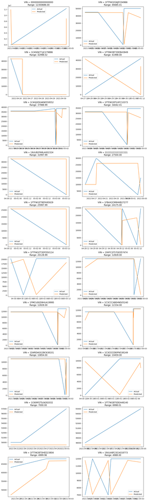

```python
import pandas as pd
import numpy as np
import matplotlib.pyplot as plt
import math

# 假设您已经有 df_pred，包含列: ['VIN', 'date', 'y_true', 'y_pred']
# 其中 y_true, y_pred 是原始价格（若之前做过 log(price+1)，请记得已做还原 exp(...) - 1）

# 1) 按 VIN 分组，计算 "波动幅度" = max(y_true) - min(y_true)
vin_ranges = []
grouped = df_pred.groupby('VIN')
for vin, group in grouped:
    price_range = group['y_true'].max() - group['y_true'].min()
    vin_ranges.append((vin, price_range))

# 2) 按波动幅度从大到小排序
vin_ranges.sort(key=lambda x: x[1], reverse=True)

# 3) 选择前 N 个 (比如 5 个) 价格波动最大的 VIN
top_n = 20
selected_vins = [x[0] for x in vin_ranges[:top_n]]

# 4) 画图: 每个 VIN 都做一张小图(subplot)
num_vins = len(selected_vins)
cols = 2  # 每行放2张图
rows = math.ceil(num_vins / cols)

fig, axes = plt.subplots(rows, cols, figsize=(12, 4*rows))
# 如果只有1行1列，axes 可能不是数组，这里统一 flatten 处理
axes = axes.flatten() if num_vins > 1 else [axes]

for i, vin_id in enumerate(selected_vins):
    ax = axes[i]

    # 提取该 VIN 的数据
    tmp = df_pred[df_pred['VIN'] == vin_id].copy()
    tmp.sort_values('date', inplace=True)

    # 绘制真实价 vs. 预测价
    ax.plot(tmp['date'], tmp['y_true'], label='Actual')
    ax.plot(tmp['date'], tmp['y_pred'], label='Predicted')

    # 标题上可加上“波动区间”辅助信息
    vin_range = vin_ranges[i][1]
    ax.set_title(f"VIN = {vin_id}\nRange: {vin_range:.2f}")
    ax.legend()

# 如果选的 top_n < rows*cols，会有多余 subplot，这里可以隐藏掉
for j in range(i+1, len(axes)):
    axes[j].set_visible(False)

plt.tight_layout()
plt.show()
```

```python
# 示例：线性回归 + 滑动窗口 flatten 后的预测
X_inf, y_inf_log, date_arr, vin_arr = build_infer_data(test_holdout_data)
y_pred_log = final_model.predict(X_inf)

# 如果训练时是 log(price+1)
# 需要还原:
y_true = np.exp(y_inf_log) - 1
y_pred = np.exp(y_pred_log) - 1

import pandas as pd

df_pred = pd.DataFrame({
    'VIN': vin_arr,
    'date': date_arr,
    'y_true': y_true,
    'y_pred': y_pred
})
df_pred.sort_values(['VIN', 'date'], inplace=True)
```

```python
# 例如，先统计每个 VIN 在 holdout 的样本数
vin_counts = df_pred['VIN'].value_counts()
top_vins = vin_counts.index[:3]  # 举例：选前3个出现样本最多的 VIN
```

```python
df_pred['AE'] = (df_pred['y_true'] - df_pred['y_pred']).abs()
df_pred['APE'] = df_pred['AE'] / (df_pred['y_true'].abs() + 1e-6)  # 避免除0
df_pred['APE%'] = df_pred['APE'] * 100
```

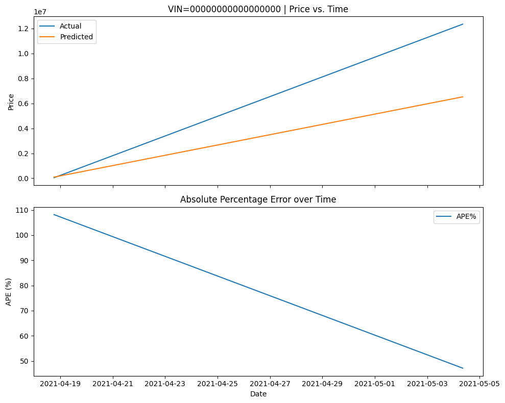

```python
import matplotlib.pyplot as plt

def plot_vin_time_series(vin_id, df):
    """
    df: DataFrame with columns [VIN, date, y_true, y_pred, AE, APE, APE%]
    """
    tmp = df[df['VIN'] == vin_id].copy()
    tmp.sort_values('date', inplace=True)

    fig, axes = plt.subplots(nrows=2, ncols=1, figsize=(10, 8), sharex=True)

    # -- (1) 上图: 真实 vs. 预测 价格
    axes[0].plot(tmp['date'], tmp['y_true'], label='Actual')
    axes[0].plot(tmp['date'], tmp['y_pred'], label='Predicted')
    axes[0].set_ylabel("Price")
    axes[0].set_title(f"VIN={vin_id} | Price vs. Time")
    axes[0].legend()

    # -- (2) 下图: 误差随时间
    # 用 APE% (百分比误差) 做例子
    axes[1].plot(tmp['date'], tmp['APE%'], label='APE%')
    axes[1].set_ylabel("APE (%)")
    axes[1].set_title("Absolute Percentage Error over Time")
    axes[1].legend()

    # X 轴
    axes[1].set_xlabel("Date")
    plt.tight_layout()
    plt.show()

# 用法: 对某个 VIN 绘图
sample_vin = df_pred['VIN'].iloc[0]
plot_vin_time_series(sample_vin, df_pred)
```

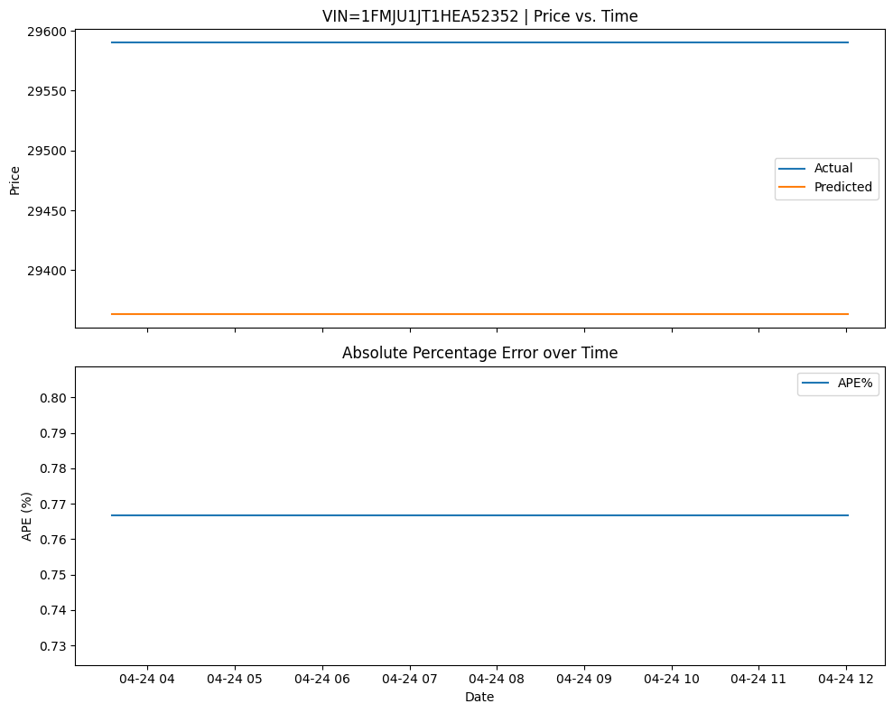

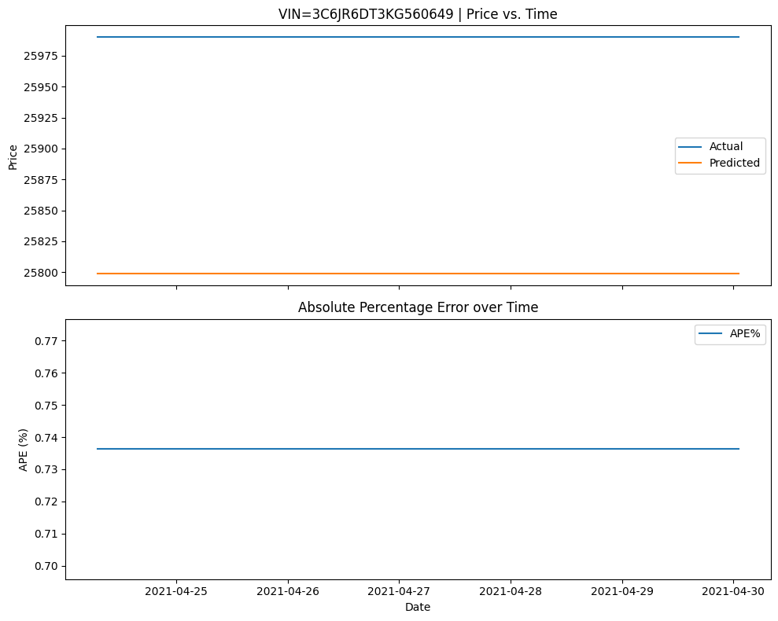

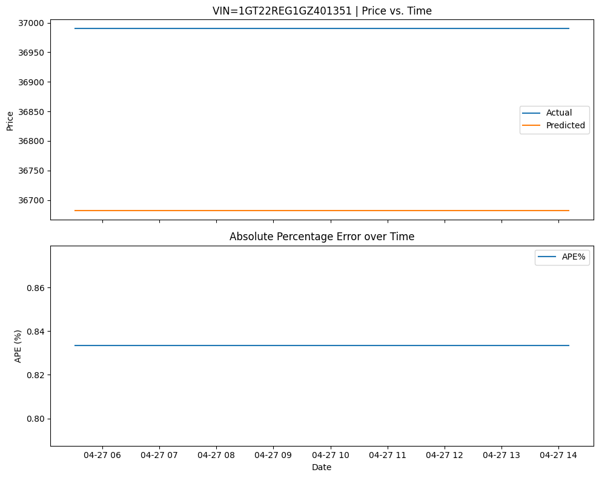

```python
representative_vins = top_vins[:3]  # 比如取3个最常见
for vin_id in representative_vins:
    plot_vin_time_series(vin_id, df_pred)
```

```python
import numpy as np

vin_stats = df_pred.groupby('VIN').agg({
    'AE': ['mean', 'std'],
    'APE%': ['mean', 'std']
}).reset_index()

vin_stats.columns = ['VIN', 'AE_mean', 'AE_std', 'APE_mean', 'APE_std']
vin_stats.sort_values('APE_mean', inplace=True)
vin_stats.head(10)
```

|  | VIN | AE_mean | AE_std | APE_mean | APE_std |
| --- | --- | --- | --- | --- | --- |
| 3160 | 3A4FY58B36T348175 | 0.057129 | NaN | 0.001430 | NaN |
| 5852 | SCBCU8ZA1AC065292 | 1.226562 | NaN | 0.001533 | NaN |
| 3035 | 2HKYF18516H512742 | 0.064697 | NaN | 0.001622 | NaN |
| 3036 | 2HKYF18526H527167 | 0.076172 | NaN | 0.001910 | NaN |
| 5548 | KMHDN56D15U136238 | 0.145020 | NaN | 0.003626 | NaN |
| 871 | 1FMZU73K03ZA83684 | 0.200195 | NaN | 0.004767 | NaN |
| 1623 | 1G1ZA5E03A4104558 | 0.182129 | NaN | 0.004957 | NaN |
| 5513 | KM8JN12D85U042715 | 0.270752 | 0.0 | 0.006777 | 0.0 |
| 594 | 1FAFP37N67W231216 | 0.335205 | 0.0 | 0.008391 | 0.0 |
| 3090 | 2T1BR32E64C270080 | 0.371094 | NaN | 0.009163 | NaN |

==============

```python
# =============================================================================
# 4. DEFINE 2 DATASET BUILDING FUNCTIONS
# =============================================================================

def build_dataset_for_train(data_list, batch_size=64, shuffle=False):
    """
    Used for model.fit() or model.evaluate().
    We only return ((X_numeric, X_vin, X_bm), y_label) to match the model's single-output structure.
    This avoids the mismatch between y_true and model outputs.
    """
    X_numeric = []
    X_vin = []
    X_bm  = []
    y_label = []

    for (num_seq, vin_seq, bm_seq, y, date_val, vin_str_val) in data_list:
        X_numeric.append(num_seq)
        X_vin.append(vin_seq)
        X_bm.append(bm_seq)
        y_label.append(y)

    X_numeric = np.array(X_numeric, dtype=np.float32)  # shape: [N, seq_len, #numeric_cols]
    X_vin     = np.array(X_vin,     dtype=np.int32)    # shape: [N, seq_len]
    X_bm      = np.array(X_bm,      dtype=np.int32)    # shape: [N, seq_len]
    y_label   = np.array(y_label,   dtype=np.float32)  # shape: [N]

    ds = tf.data.Dataset.from_tensor_slices(((X_numeric, X_vin, X_bm), y_label))
    if shuffle:
        ds = ds.shuffle(len(data_list))
    ds = ds.batch(batch_size)
    return ds

def build_dataset_for_inference(data_list, batch_size=64):
    """
    Used for inference/visualization where we want the date/VIN as well.
    We return ((X_numeric, X_vin, X_bm), (y_label, date_str, vin_str)),
    so we can manually call model.predict(...) while retaining date & VIN info.
    """
    X_numeric = []
    X_vin = []
    X_bm  = []
    y_label = []
    date_list = []
    vin_list  = []

    for (num_seq, vin_seq, bm_seq, y, date_val, vin_str_val) in data_list:
        X_numeric.append(num_seq)
        X_vin.append(vin_seq)
        X_bm.append(bm_seq)
        y_label.append(y)
        date_list.append(str(date_val))   # convert to string to avoid TensorFlow type issues
        vin_list.append(str(vin_str_val))

    X_numeric = np.array(X_numeric, dtype=np.float32)
    X_vin     = np.array(X_vin,     dtype=np.int32)
    X_bm      = np.array(X_bm,      dtype=np.int32)
    y_label   = np.array(y_label,   dtype=np.float32)
    date_list = np.array(date_list)
    vin_list  = np.array(vin_list)

    ds = tf.data.Dataset.from_tensor_slices(
        ((X_numeric, X_vin, X_bm), (y_label, date_list, vin_list))
    )
    ds = ds.batch(batch_size)
    return ds
```

```python
# =============================================================================
# 5. CREATE MODEL + CROSS VALIDATION
# =============================================================================

def create_model(embedding_dim, lstm_hidden_size, learning_rate):
    """
    Build a Keras model with:
      - 3 inputs: numeric_input, vin_input, bm_input
      - 1 LSTM layer to encode the sequence
      - 1 Dense output for price prediction
    """
    vin_vocab_size = len(vin_list)
    bm_vocab_size  = len(bm_list)

    # Inputs
    input_numeric = keras.Input(shape=(seq_len, len(numeric_cols)), name='numeric_input')
    input_vin     = keras.Input(shape=(seq_len,), dtype='int32', name='vin_input')
    input_bm      = keras.Input(shape=(seq_len,), dtype='int32', name='bm_input')

    # Embedding layers for VIN & brand_model
    vin_emb_layer = keras.layers.Embedding(vin_vocab_size, embedding_dim, name='vin_embedding')
    bm_emb_layer  = keras.layers.Embedding(bm_vocab_size,  embedding_dim, name='bm_embedding')

    vin_emb_seq = vin_emb_layer(input_vin)  # shape [batch, seq_len, emb_dim]
    bm_emb_seq  = bm_emb_layer(input_bm)    # shape [batch, seq_len, emb_dim]

    # Concatenate numeric + vin_emb + bm_emb
    concat_seq = keras.layers.Concatenate(axis=-1)([input_numeric, vin_emb_seq, bm_emb_seq])

    # LSTM layer
    lstm_out = keras.layers.LSTM(lstm_hidden_size, return_sequences=False)(concat_seq)

    # Final dense layer => 1 output for price
    output_price = keras.layers.Dense(1)(lstm_out)

    # Build model
    model = keras.Model(inputs=[input_numeric, input_vin, input_bm], outputs=output_price)
    optimizer = keras.optimizers.Adam(learning_rate=learning_rate, clipnorm=1.0)
    model.compile(optimizer=optimizer, loss='mse')
    return model

def k_fold_split(data, k=3):
    """
    Manually split 'data' into k folds, each fold has ~len(data)//k samples.
    Returns a list of (train_data, val_data) pairs.
    """
    fold_size = len(data) // k
    folds = []
    for i in range(k):
        val_start = i * fold_size
        val_end   = (i + 1) * fold_size
        val_data = data[val_start:val_end]
        train_data = data[:val_start] + data[val_end:]
        folds.append((train_data, val_data))
    return folds

# Param grid for hyperparameter tuning
param_grid = [
    {'embedding_dim': 8,  'lstm_hidden_size': 32,  'learning_rate': 1e-3},
    {'embedding_dim': 16, 'lstm_hidden_size': 64,  'learning_rate': 1e-4},
    {'embedding_dim': 16, 'lstm_hidden_size': 128, 'learning_rate': 1e-4},
]

# 3-fold split for cross validation
folds = k_fold_split(cv_data, k=3)

best_param = None
best_cv_mse = float('inf')
print("Starting Hyperparameter Search with 3-Fold CV...")

for param in param_grid:
    emb_dim  = param['embedding_dim']
    lstm_size = param['lstm_hidden_size']
    lr       = param['learning_rate']

    fold_mses = []
    for fold_i, (train_list, val_list) in enumerate(folds):
        # Build train & val Datasets (no date/vin info for Keras .fit)
        train_ds_cv = build_dataset_for_train(train_list, batch_size=64, shuffle=True)
        val_ds_cv   = build_dataset_for_train(val_list,   batch_size=64, shuffle=False)

        # Create model for this fold
        model_cv = create_model(emb_dim, lstm_size, lr)
        # Train for a few epochs to evaluate
        history_cv = model_cv.fit(
            train_ds_cv,
            validation_data=val_ds_cv,
            epochs=5,
            verbose=0
        )

        # Evaluate on validation set
        val_mse = model_cv.evaluate(val_ds_cv, verbose=0)
        fold_mses.append(val_mse)
        print(f"  Fold {fold_i+1}, Params={param}, Val MSE={val_mse:.4f}")

    avg_mse = np.mean(fold_mses)
    print(f"=> Params={param} => average CV MSE={avg_mse:.4f}")
    if avg_mse < best_cv_mse:
        best_cv_mse = avg_mse
        best_param = param

print("Best Hyperparams:", best_param)
print("Corresponding CV MSE:", best_cv_mse)
```

```
Starting Hyperparameter Search with 3-Fold CV...
  Fold 1, Params={'embedding_dim': 8, 'lstm_hidden_size': 32, 'learning_rate': 0.001}, Val MSE=1.1528
  Fold 2, Params={'embedding_dim': 8, 'lstm_hidden_size': 32, 'learning_rate': 0.001}, Val MSE=1.3257
  Fold 3, Params={'embedding_dim': 8, 'lstm_hidden_size': 32, 'learning_rate': 0.001}, Val MSE=1.4856
=> Params={'embedding_dim': 8, 'lstm_hidden_size': 32, 'learning_rate': 0.001} => average CV MSE=1.3214
  Fold 1, Params={'embedding_dim': 16, 'lstm_hidden_size': 64, 'learning_rate': 0.0001}, Val MSE=4.8033
  Fold 2, Params={'embedding_dim': 16, 'lstm_hidden_size': 64, 'learning_rate': 0.0001}, Val MSE=18.0912
  Fold 3, Params={'embedding_dim': 16, 'lstm_hidden_size': 64, 'learning_rate': 0.0001}, Val MSE=8.5439
=> Params={'embedding_dim': 16, 'lstm_hidden_size': 64, 'learning_rate': 0.0001} => average CV MSE=10.4795
  Fold 1, Params={'embedding_dim': 16, 'lstm_hidden_size': 128, 'learning_rate': 0.0001}, Val MSE=1.1327
  Fold 2, Params={'embedding_dim': 16, 'lstm_hidden_size': 128, 'learning_rate': 0.0001}, Val MSE=1.2755
  Fold 3, Params={'embedding_dim': 16, 'lstm_hidden_size': 128, 'learning_rate': 0.0001}, Val MSE=1.4191
=> Params={'embedding_dim': 16, 'lstm_hidden_size': 128, 'learning_rate': 0.0001} => average CV MSE=1.2758
Best Hyperparams: {'embedding_dim': 16, 'lstm_hidden_size': 128, 'learning_rate': 0.0001}
Corresponding CV MSE: 1.275767723719279
```

```
Retrain with Best Hyperparams on entire CV dataset...
999/999 ━━━━━━━━━━━━━━━━━━━━ 6s 5ms/step - loss: 70.6935
999/999 ━━━━━━━━━━━━━━━━━━━━ 5s 5ms/step - loss: 12.1144
999/999 ━━━━━━━━━━━━━━━━━━━━ 5s 5ms/step - loss: 1.2763
999/999 ━━━━━━━━━━━━━━━━━━━━ 5s 5ms/step - loss: 1.2121
999/999 ━━━━━━━━━━━━━━━━━━━━ 5s 5ms/step - loss: 1.2230
999/999 ━━━━━━━━━━━━━━━━━━━━ 5s 5ms/step - loss: 1.2293
999/999 ━━━━━━━━━━━━━━━━━━━━ 5s 5ms/step - loss: 1.2854
999/999 ━━━━━━━━━━━━━━━━━━━━ 5s 5ms/step - loss: 1.2618
999/999 ━━━━━━━━━━━━━━━━━━━━ 5s 5ms/step - loss: 1.1694
999/999 ━━━━━━━━━━━━━━━━━━━━ 5s 5ms/step - loss: 1.2834

[FINAL TEST] MSE=1.2116, RMSE=1.1007
```

[figure not shown]

```python
# =============================================================================
# 6. RETRAIN ON ALL CV DATA WITH BEST PARAM & EVALUATE ON HOLDOUT
# =============================================================================

print("\nRetrain with Best Hyperparams on entire CV dataset...")

# Build a training dataset from all cv_data
train_ds_final = build_dataset_for_train(cv_data, batch_size=64, shuffle=True)
best_model = create_model(
    embedding_dim=best_param['embedding_dim'],
    lstm_hidden_size=best_param['lstm_hidden_size'],
    learning_rate=best_param['learning_rate']
)

# Train with more epochs
history_final = best_model.fit(train_ds_final, epochs=10, verbose=1)

# Build a dataset from holdout data to calculate final MSE/RMSE
test_ds_holdout_for_loss = build_dataset_for_train(test_holdout_data, batch_size=64, shuffle=False)
test_mse = best_model.evaluate(test_ds_holdout_for_loss, verbose=0)
test_rmse = math.sqrt(test_mse)
print(f"\n[FINAL TEST] MSE={test_mse:.4f}, RMSE={test_rmse:.4f}")

# Optional: Plot the training loss curve
plt.figure()
plt.plot(history_final.history['loss'], label='Train Loss')
plt.title("Final Training Loss Curve (Best Hyperparams)")
plt.xlabel('Epoch')
plt.ylabel('MSE')
plt.legend()
plt.show()
```

```python
# =============================================================================
# 7. INFERENCE / VISUALIZATION: COLLECT (date, VIN, y_pred, y_true)
# =============================================================================

print("\nInference with date & VIN for Time Series Visualization...")

# Build a dataset that returns (y_label, date, vin) as well
test_ds_holdout_for_infer = build_dataset_for_inference(test_holdout_data, batch_size=64)

y_preds_log = []
y_trues_log = []
dates_list  = []
vins_list   = []

for (X_batch, Y_info_batch) in test_ds_holdout_for_infer:
    # Y_info_batch => (y_label, date_str, vin_str)
    y_label_batch, date_batch, vin_batch = Y_info_batch

    # Predict: shape => [batch_size, 1]
    preds = best_model.predict(X_batch)

    y_preds_log.extend(preds.ravel().tolist())
    y_trues_log.extend(y_label_batch.numpy().tolist())
    dates_list.extend(date_batch.numpy().tolist())
    vins_list.extend(vin_batch.numpy().tolist())

# Step: revert log(price+1) => original price
y_preds = np.exp(y_preds_log) - 1
y_trues = np.exp(y_trues_log) - 1

# Make a dataframe to store prediction results
df_pred = pd.DataFrame({
    'VIN': [v.decode('utf-8') if isinstance(v, bytes) else v for v in vins_list],
    'date': [
        pd.to_datetime(d.decode('utf-8')) if isinstance(d, bytes) else pd.to_datetime(d)
        for d in dates_list
    ],
    'y_true': y_trues,
    'y_pred': y_preds
})
df_pred.sort_values(by=['VIN', 'date'], inplace=True)
```

[output not shown]

[output cut: 196 more lines]

[output not shown]

[output not shown]

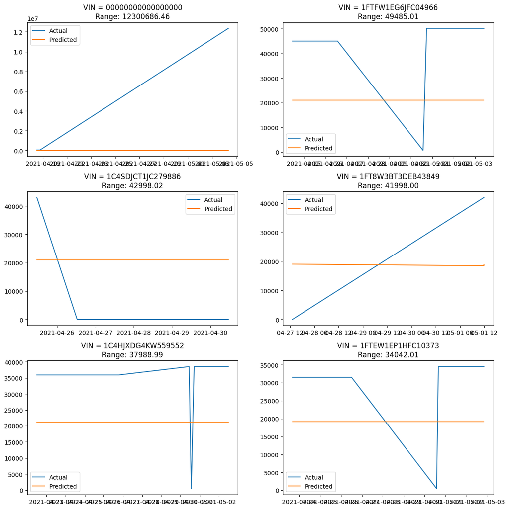

```python
import pandas as pd
import numpy as np
import matplotlib.pyplot as plt
import math

# 假设您已经有 df_pred，包含列: ['VIN', 'date', 'y_true', 'y_pred']
# 其中 y_true, y_pred 是原始价格（若之前做过 log(price+1)，请记得已做还原 exp(...) - 1）

# 1) 按 VIN 分组，计算 "波动幅度" = max(y_true) - min(y_true)
vin_ranges = []
grouped = df_pred.groupby('VIN')
for vin, group in grouped:
    price_range = group['y_true'].max() - group['y_true'].min()
    vin_ranges.append((vin, price_range))

# 2) 按波动幅度从大到小排序
vin_ranges.sort(key=lambda x: x[1], reverse=True)

# 3) 选择前 N 个 (比如 5 个) 价格波动最大的 VIN
top_n = 5
selected_vins = [x[0] for x in vin_ranges[:top_n + 1]]

# 4) 画图: 每个 VIN 都做一张小图(subplot)
num_vins = len(selected_vins)
cols = 2  # 每行放2张图
rows = math.ceil(num_vins / cols)

fig, axes = plt.subplots(rows, cols, figsize=(12, 4*rows))
# 如果只有1行1列，axes 可能不是数组，这里统一 flatten 处理
axes = axes.flatten() if num_vins > 1 else [axes]

for i, vin_id in enumerate(selected_vins):
    ax = axes[i]

    # 提取该 VIN 的数据
    tmp = df_pred[df_pred['VIN'] == vin_id].copy()
    tmp.sort_values('date', inplace=True)

    # 绘制真实价 vs. 预测价
    ax.plot(tmp['date'], tmp['y_true'], label='Actual')
    ax.plot(tmp['date'], tmp['y_pred'], label='Predicted')

    # 标题上可加上“波动区间”辅助信息
    vin_range = vin_ranges[i][1]
    ax.set_title(f"VIN = {vin_id}\nRange: {vin_range:.2f}")
    ax.legend()

# 如果选的 top_n < rows*cols，会有多余 subplot，这里可以隐藏掉
for j in range(i+1, len(axes)):
    axes[j].set_visible(False)

plt.tight_layout()
plt.show()
```

```python
import numpy as np

def build_Xy_for_linear(data_list, seq_len=3):
    """
    data_list 每个元素: (X_seq_numeric, X_seq_vin, X_seq_bm, y_price, y_date, vin_str)
    X_seq_numeric shape = [seq_len, num_numeric_features]
    扁平化 X_seq_numeric => [seq_len * num_numeric_features]
    返回: X, y
    """
    X_list = []
    y_list = []
    for (num_seq, vin_seq, bm_seq, y, y_date, vin_str) in data_list:
        # num_seq shape => (seq_len, num_numeric_features)
        # flatten:
        x_flat = num_seq.flatten()  # shape (seq_len * num_numeric_features,)

        X_list.append(x_flat)
        y_list.append(y)

    X = np.array(X_list, dtype=np.float32)
    y = np.array(y_list, dtype=np.float32)
    return X, y
```

# Trainning & Fitting Machine Learning Models

## 1. Linear Regression Model: Ridge Regression

### Rationale of Selection

- Ridge Regression adds an L2 penalty to the loss function. This shrinks coefficients but generally keeps all features in the model.
- Lasso (L1 penalty) tends to zero out coefficients of less important features, effectively performing feature selection. This can be useful in some scenarios, but it can also drop too many correlated features and become unstable if you want to leverage those correlations.
- In real-world used-car datasets, you may have correlated features (e.g., year and odometer, or manufacturer and model). Ridge handles multicollinearity more gracefully—rather than arbitrarily zeroing out correlated features, it shrinks them equally. This usually yields more stable results.
- Elastic Net (a mix of L1 and L2) is also a possibility, but if you don’t specifically need feature selection from Lasso, Ridge is a solid, simpler choice

### Strengths

- Very fast to train on large tabular data.
- Interpretability: You can easily examine which features have higher coefficients.
- Good baseline to quickly gauge your data’s linear separability.

### Weaknesses

- Struggles with non-linear relationships unless you manually engineer polynomial or interaction terms.
- May still underfit if the real relationship between features and price is complex.

### Rationale of Selection

- Random Forest is an ensemble of many decision trees, each trained on different subsets of the data (rows and/or columns).
- It naturally captures non-linearities and feature interactions without extensive feature engineering.
- It is fairly robust to outliers and can handle missing values (with proper strategy or imputation).
- Typically achieves strong performance on tabular data.

### Strengths

- High predictive power and often outperforms simple linear models.
- Inherent feature importance assessment, which helps with interpretability.
- Averaging across multiple trees reduces overfitting compared to a single decision tree.

### Weaknesses

- Can be memory-intensive if a large number of trees is used.
- Predictions can be slower due to the need to average many decision trees.
- Less straightforward to interpret compared to a pure linear model (though feature importances can mitigate that).

### Rationale of Selection

- A feedforward MLP is generally the best neural network choice for tabular data (as opposed to CNNs for image data or LSTMs for sequence data).
- Can capture complex non-linear relationships if given enough layers/neurons.
- Offers flexibility with different architectures, regularization schemes (dropout, batch normalization), and activation functions.

### Strengths

- Highly flexible universal approximator; can learn intricate patterns in the data.
- Scales well with more data, potentially outperforming simpler models given sufficient examples.
- Possible to use embedding layers for high-cardinality categorical features, reducing dimensionality.

### Weaknesses

- Tuning hyperparameters (number of layers, neurons, learning rate, etc.) can be complex and time-consuming.
- More prone to overfitting if not properly regularized.
- Less interpretable compared to linear or tree-based models.

```python
num_unique_vin = df_cleaned['VIN'].nunique(dropna=True)
print("number of unique vin", num_unique_vin)

num_unique_id = df_cleaned['id'].nunique(dropna=True)
print("number of unique id", num_unique_id)
```

### Rationale of Selection

- **KNN Regressor** predicts a target value based on the average (or another aggregation) of the k nearest neighbors in feature space.
- No explicit “training” phase—KNN stores the entire dataset and performs distance-based lookups during prediction.
- Can handle complex boundaries since the decision (or prediction) is based purely on local neighbor information.

### Strengths

- Simple to implement and understand conceptually.
- Naturally captures non-linear relationships if the data in the local neighborhood is consistent.
- Few parameters: mainly k (number of neighbors) and distance metric (e.g., Euclidean).

### Weaknesses

- Can be **slow at prediction time** for large datasets because it must search through all or a large portion of the data.
- **Sensitive to feature scaling**—proper normalization/standardization is crucial.
- Choosing the optimal number of neighbors (k) can be non-trivial and must be tuned with techniques like cross-validation.

[output not shown]